# Impact of Covid-19 on Air Traffic in Europe

Stephen Sani

2024-04-08

## Introduction

Covid-19 is probably the most important single event in the year 2019. As the virus spread across the globe, governments around the world began to take measures to curb the transmission of the virus. One such measures was restrictions on air travels in addition, some imposed a total loackdown of part orentire country. The measures taken seem to immediately affected air travel and it is widely believed that covid-19 have affected most aspects of human lives. In this report, we will investigate the impact of covid-19 and associated restrictions on air traffic. The data source is from Eurocontrol. Eurocontrol minitors air traffic in airports across Europe. For example, we are interestes in 1. the trend of total traffic by year 2. the trend of difference between arrival and departure 3. The effect on top ten airports with highest traffic in 2019 and 2020.

### Load required R packages

The analysis require some packages that must be loaded to R

### Download data file

Next we download the data to the data directory from the url at https://www.eurocontrol.int/performance/data/download/xls/Airport_Traffic.xlsx The file was opened in Excel, metadata worksheets were removed and the file was saved to .csv(utf8) in the data directory.

### Read the data from file

Next we read the data from the file

## Data Exploration

We preview first 6 observations

| YEAR | MONTH_NUM | MONTH_MON | FLT_DATE | APT_ICAO | APT_NAME | STATE_NAME | FLT_DEP_1 | FLT_ARR_1 | FLT_TOT_1 | FLT_DEP_IFR_2 | FLT_ARR_IFR_2 | FLT_TOT_IFR_2 | Pivot Label |
| --- | --- | --- | --- | --- | --- | --- | --- | --- | --- | --- | --- | --- | --- |
| 2016 | 1 | JAN | 1/1/2016 | EBAW | Antwerp | Belgium | 4 | 3 | 7 | NA | NA | NA | Antwerp (EBAW) |
| 2016 | 1 | JAN | 1/1/2016 | EBBR | Brussels | Belgium | 174 | 171 | 345 | 174 | 161 | 335 | Brussels (EBBR) |
| 2016 | 1 | JAN | 1/1/2016 | EBCI | Charleroi | Belgium | 45 | 47 | 92 | 45 | 45 | 90 | Charleroi (EBCI) |
| 2016 | 1 | JAN | 1/1/2016 | EBLG | Liège | Belgium | 6 | 7 | 13 | NA | NA | NA | Liège (EBLG) |
| 2016 | 1 | JAN | 1/1/2016 | EBOS | Ostend-Bruges | Belgium | 7 | 7 | 14 | NA | NA | NA | Ostend-Bruges (EBOS) |
| 2016 | 1 | JAN | 1/1/2016 | EDDB | Berlin - Brandenburg | Germany | 98 | 99 | 197 | NA | NA | NA | Berlin - Brandenburg (EDDB) |

Let us print the column names.

```
##  [1] "YEAR"          "MONTH_NUM"     "MONTH_MON"     "FLT_DATE"
##  [5] "APT_ICAO"      "APT_NAME"      "STATE_NAME"    "FLT_DEP_1"
##  [9] "FLT_ARR_1"     "FLT_TOT_1"     "FLT_DEP_IFR_2" "FLT_ARR_IFR_2"
## [13] "FLT_TOT_IFR_2" "Pivot Label"
```

The column names require cleaning.

Let us get technical details of the data

```
## Rows: 764,508
## Columns: 14
## $ YEAR          <dbl> 2016, 2016, 2016, 2016, 2016, 2016, 2016, 2016, 2016, 20…
## $ MONTH_NUM     <dbl> 1, 1, 1, 1, 1, 1, 1, 1, 1, 1, 1, 1, 1, 1, 1, 1, 1, 1, 1,…
## $ MONTH_MON     <chr> "JAN", "JAN", "JAN", "JAN", "JAN", "JAN", "JAN", "JAN", …
## $ FLT_DATE      <chr> "1/1/2016", "1/1/2016", "1/1/2016", "1/1/2016", "1/1/201…
## $ APT_ICAO      <chr> "EBAW", "EBBR", "EBCI", "EBLG", "EBOS", "EDDB", "EDDC", …
## $ APT_NAME      <chr> "Antwerp", "Brussels", "Charleroi", "Liège", "Ostend-Bru…
## $ STATE_NAME    <chr> "Belgium", "Belgium", "Belgium", "Belgium", "Belgium", "…
## $ FLT_DEP_1     <dbl> 4, 174, 45, 6, 7, 98, 18, 1, 401, 3, 122, 92, 172, 276, …
## $ FLT_ARR_1     <dbl> 3, 171, 47, 7, 7, 99, 21, 1, 341, 4, 130, 90, 175, 236, …
## $ FLT_TOT_1     <dbl> 7, 345, 92, 13, 14, 197, 39, 2, 742, 7, 252, 182, 347, 5…
## $ FLT_DEP_IFR_2 <dbl> NA, 174, 45, NA, NA, NA, NA, NA, 401, NA, 125, NA, NA, 2…
## $ FLT_ARR_IFR_2 <dbl> NA, 161, 45, NA, NA, NA, NA, NA, 306, NA, 129, NA, NA, 2…
## $ FLT_TOT_IFR_2 <dbl> NA, 335, 90, NA, NA, NA, NA, NA, 707, NA, 254, NA, NA, 5…
## $ `Pivot Label` <chr> "Antwerp (EBAW)", "Brussels (EBBR)", "Charleroi (EBCI)",…
```

Some column data types could be adjusted The same information and more could be seen when we display the structure of the data

```
## spc_tbl_ [764,508 × 14] (S3: spec_tbl_df/tbl_df/tbl/data.frame)
##  $ YEAR         : num [1:764508] 2016 2016 2016 2016 2016 ...
##  $ MONTH_NUM    : num [1:764508] 1 1 1 1 1 1 1 1 1 1 ...
##  $ MONTH_MON    : chr [1:764508] "JAN" "JAN" "JAN" "JAN" ...
##  $ FLT_DATE     : chr [1:764508] "1/1/2016" "1/1/2016" "1/1/2016" "1/1/2016" ...
##  $ APT_ICAO     : chr [1:764508] "EBAW" "EBBR" "EBCI" "EBLG" ...
##  $ APT_NAME     : chr [1:764508] "Antwerp" "Brussels" "Charleroi" "Liège" ...
##  $ STATE_NAME   : chr [1:764508] "Belgium" "Belgium" "Belgium" "Belgium" ...
##  $ FLT_DEP_1    : num [1:764508] 4 174 45 6 7 98 18 1 401 3 ...
##  $ FLT_ARR_1    : num [1:764508] 3 171 47 7 7 99 21 1 341 4 ...
##  $ FLT_TOT_1    : num [1:764508] 7 345 92 13 14 197 39 2 742 7 ...
##  $ FLT_DEP_IFR_2: num [1:764508] NA 174 45 NA NA NA NA NA 401 NA ...
##  $ FLT_ARR_IFR_2: num [1:764508] NA 161 45 NA NA NA NA NA 306 NA ...
##  $ FLT_TOT_IFR_2: num [1:764508] NA 335 90 NA NA NA NA NA 707 NA ...
##  $ Pivot Label  : chr [1:764508] "Antwerp (EBAW)" "Brussels (EBBR)" "Charleroi (EBCI)" "Liège (EBLG)" ...
##  - attr(*, "spec")=
##   .. cols(
##   ..   YEAR = col_double(),
##   ..   MONTH_NUM = col_double(),
##   ..   MONTH_MON = col_character(),
##   ..   FLT_DATE = col_character(),
##   ..   APT_ICAO = col_character(),
##   ..   APT_NAME = col_character(),
##   ..   STATE_NAME = col_character(),
##   ..   FLT_DEP_1 = col_double(),
##   ..   FLT_ARR_1 = col_double(),
##   ..   FLT_TOT_1 = col_double(),
##   ..   FLT_DEP_IFR_2 = col_double(),
##   ..   FLT_ARR_IFR_2 = col_double(),
##   ..   FLT_TOT_IFR_2 = col_double(),
##   ..   `Pivot Label` = col_character()
##   .. )
##  - attr(*, "problems")=<externalptr>
```

### Data cleaning

Let us clean the culumn names

```
##  [1] "year"          "month_num"     "month_mon"     "flt_date"
##  [5] "apt_icao"      "apt_name"      "state_name"    "flt_dep_1"
##  [9] "flt_arr_1"     "flt_tot_1"     "flt_dep_ifr_2" "flt_arr_ifr_2"
## [13] "flt_tot_ifr_2" "pivot_label"
```

Let us fix relevant column data types: flt_date as date and year as integer

### Are there missing values?

```
##          year     month_num     month_mon      flt_date      apt_icao
##             0             0             0             0             0
##      apt_name    state_name     flt_dep_1     flt_arr_1     flt_tot_1
##             0             0             0             0             0
## flt_dep_ifr_2 flt_arr_ifr_2 flt_tot_ifr_2   pivot_label
##        532987        532987        532987             0
```

Yes there are missing values.

Which columns have missing values

```
## [1] "flt_dep_ifr_2" "flt_arr_ifr_2" "flt_tot_ifr_2"
```

Let us preview records with missing values

| year | month_num | month_mon | flt_date | apt_icao | apt_name | state_name | flt_dep_1 | flt_arr_1 | flt_tot_1 | flt_dep_ifr_2 | flt_arr_ifr_2 | flt_tot_ifr_2 | pivot_label |
| --- | --- | --- | --- | --- | --- | --- | --- | --- | --- | --- | --- | --- | --- |
| 2016 | 1 | JAN | 2016-01-01 | EBAW | Antwerp | Belgium | 4 | 3 | 7 | NA | NA | NA | Antwerp (EBAW) |
| 2016 | 1 | JAN | 2016-01-01 | EBLG | Liège | Belgium | 6 | 7 | 13 | NA | NA | NA | Liège (EBLG) |
| 2016 | 1 | JAN | 2016-01-01 | EBOS | Ostend-Bruges | Belgium | 7 | 7 | 14 | NA | NA | NA | Ostend-Bruges (EBOS) |
| 2016 | 1 | JAN | 2016-01-01 | EDDB | Berlin - Brandenburg | Germany | 98 | 99 | 197 | NA | NA | NA | Berlin - Brandenburg (EDDB) |
| 2016 | 1 | JAN | 2016-01-01 | EDDC | Dresden | Germany | 18 | 21 | 39 | NA | NA | NA | Dresden (EDDC) |
| 2016 | 1 | JAN | 2016-01-01 | EDDE | Erfurt | Germany | 1 | 1 | 2 | NA | NA | NA | Erfurt (EDDE) |
| 2016 | 1 | JAN | 2016-01-01 | EDDG | Muenster-Osnabrueck | Germany | 3 | 4 | 7 | NA | NA | NA | Muenster-Osnabrueck (EDDG) |
| 2016 | 1 | JAN | 2016-01-01 | EDDK | Cologne-Bonn | Germany | 92 | 90 | 182 | NA | NA | NA | Cologne-Bonn (EDDK) |
| 2016 | 1 | JAN | 2016-01-01 | EDDL | Dusseldorf | Germany | 172 | 175 | 347 | NA | NA | NA | Dusseldorf (EDDL) |
| 2016 | 1 | JAN | 2016-01-01 | EDDR | Saarbruecken | Germany | 3 | 3 | 6 | NA | NA | NA | Saarbruecken (EDDR) |

[output cut: 9990 more lines]

All missing values are from airport operator. Missing values not entered by airport operator are already captured by network manager. we will use entries from network manager. Let us drop all entries from airport operator as most of them are missing.

### explore the individual variables.

```
## [1] FALSE
```

Turns out although we expect the number of unique entries in apt_icao and apt_name to be the same, they in fact are not the same. Further investigation revealed that apt_icao “LLBG” have two different apt_name

| apt_icao |
| --- |
| LLBG |

Note: only column apt_icao is a unique identifier

## Descriptive statistics of numeric variables

We print descriptive statistics for all numeric variables

```
##       year        month_num       flt_dep_1        flt_arr_1
##  Min.   :2016   Min.   : 1.00   Min.   :  0.00   Min.   :  0.00
##  1st Qu.:2017   1st Qu.: 3.00   1st Qu.:  5.00   1st Qu.:  5.00
##  Median :2019   Median : 7.00   Median : 18.00   Median : 18.00
##  Mean   :2019   Mean   : 6.47   Mean   : 63.64   Mean   : 63.68
##  3rd Qu.:2021   3rd Qu.: 9.00   3rd Qu.: 71.00   3rd Qu.: 71.00
##  Max.   :2023   Max.   :12.00   Max.   :847.00   Max.   :813.00
##    flt_tot_1
##  Min.   :   0.0
##  1st Qu.:  10.0
##  Median :  35.0
##  Mean   : 127.3
##  3rd Qu.: 143.0
##  Max.   :1628.0
```

## Summary of traffic by year

| year | arrival | departure | total | diff_arr_dep | era |
| --- | --- | --- | --- | --- | --- |
| 2016 | 7629578 | 7626163 | 15255741 | 3415 | pre_covid |
| 2017 | 7901230 | 7897408 | 15798638 | 3822 | pre_covid |
| 2018 | 8511971 | 8508147 | 17020118 | 3824 | pre_covid |
| 2019 | 8594280 | 8591631 | 17185911 | 2649 | covid |
| 2020 | 3710875 | 3706141 | 7417016 | 4734 | post_covid |
| 2021 | 4629278 | 4623315 | 9252593 | 5963 | post_covid |
| 2022 | 7181622 | 7175350 | 14356972 | 6272 | post_covid |

## Data Visualization

Lets visualize trend of total fights by year

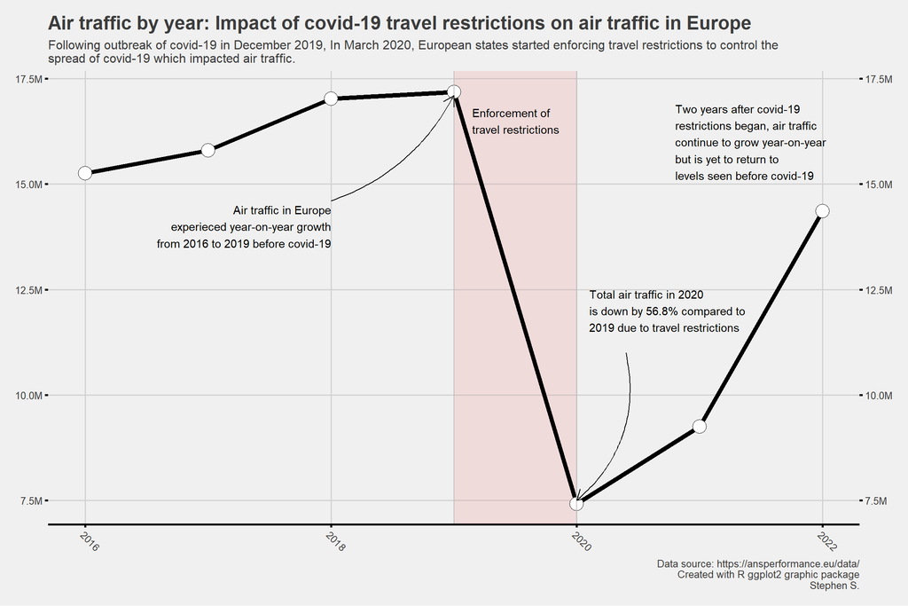

Lets visualize trend of difference in arrival and departure traffic by year

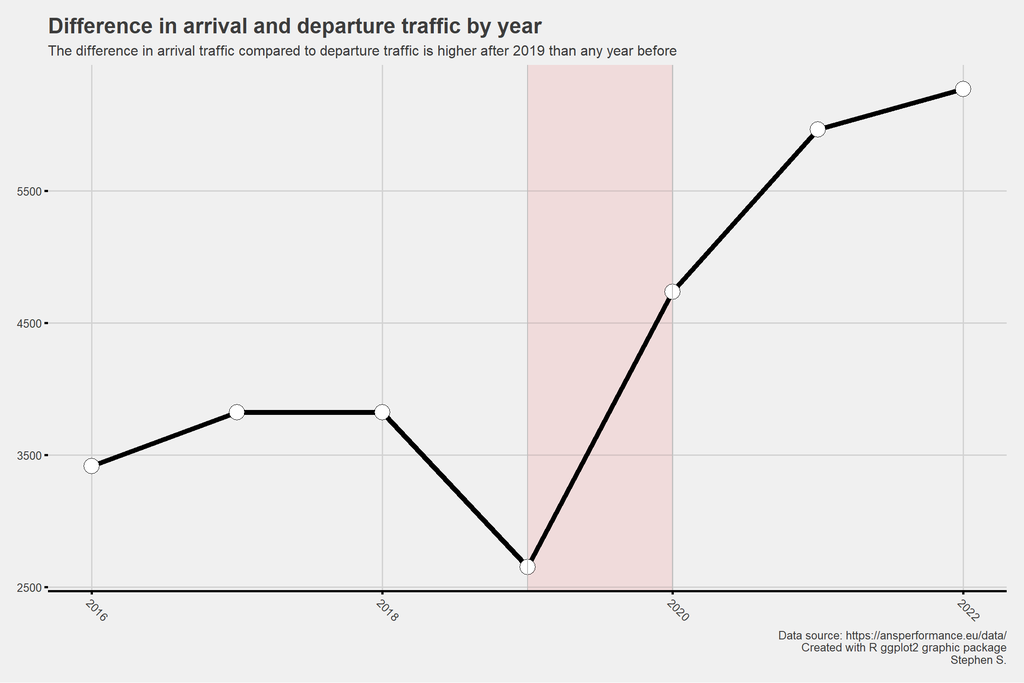

Lets visualize seasonal trend of total traffic by months over the years

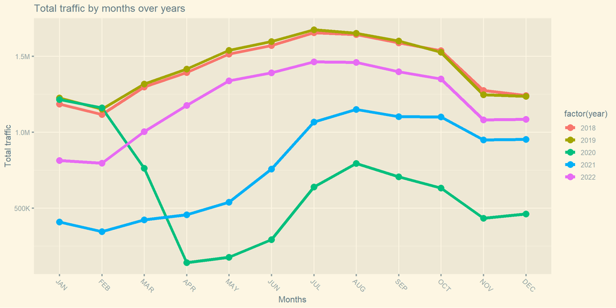

Lets visualize relationship between arrival and departure over the years

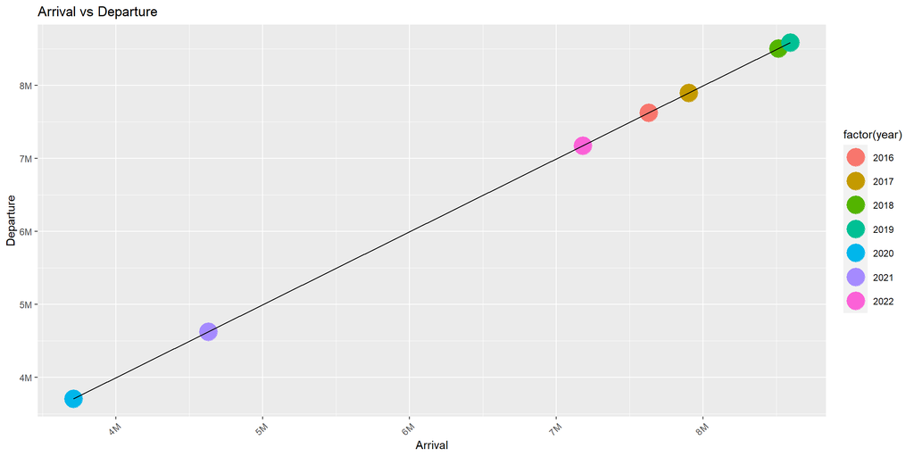

Which airports have top ten number of traffic in 2019

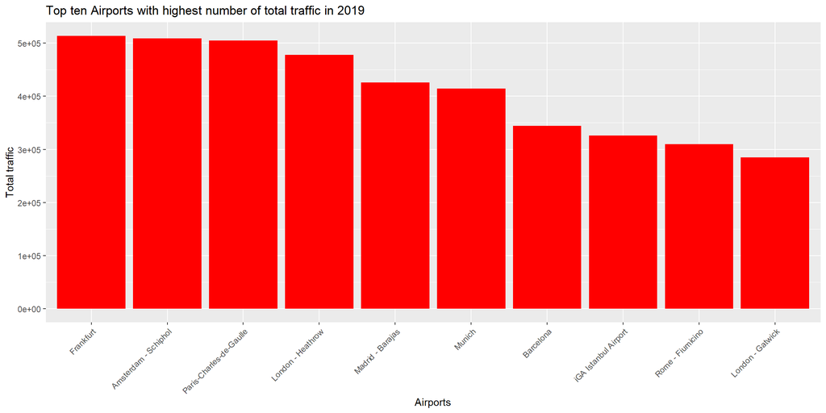

Which airports have top ten number of traffic in 2020

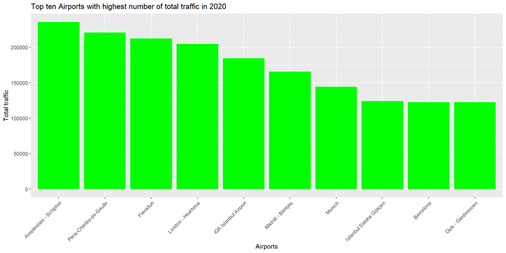

Combine plots from traffic data

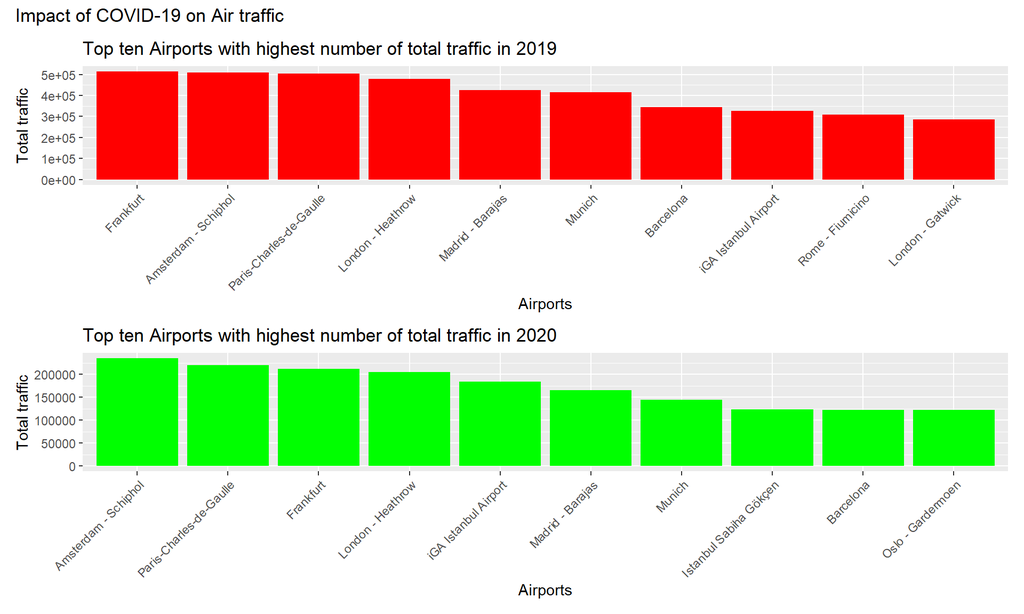

## Conclussion

Covid-19 and the associated measures taken by governments around the word to control its spread have led to a decrease in air traffic in European states. In addition, the difference in the number of arrival and number of departure have increased in the years following covid-19 in comparison to the years before covid-19. Finally, while all airports have been impacted, most of the top ten airports with the highest traffic before covid-19 continue to be among the top ten performers even after covid-19.